# Part II - (Prosper Loan Data)

## by (Ijeoma Mariam Okocha - mariokocha@gmail.com)

## Investigation Overview

> There are three main features i looked at and they are; a. Estimated Returns -- The estimated return assigned to the listing at the time it was created. Estimated return is the difference between the Estimated Effective Yield and the Estimated Loss Rate. Applicable for loans originated after July 2009. b. BorrowerAPR -- The Borrower's cost rate for this loan. c. CurrentDelinquencies -- Number of accounts delinquent at the time the credit profile was pulled.

## Dataset Overview

> There are 113937 entries of loan data and 81 columns where 61 columns are numerical, 3 boolean and the rest strings (although there are date-type represented as objects) We would just select a few columns to work with The current status of the loan: Cancelled, Chargedoff, Completed, Current, Defaulted, FinalPaymentInProgress, PastDue. The PastDue status will be accompanied by a delinquency bucket.The Prosper Rating assigned at the time the listing was created: 0 - N/A, 1 - HR, 2 - E, 3 - D, 4 - C, 5 - B, 6 - A, 7 - AA. Applicable for loans originated after July 2009.The Prosper Rating assigned at the time the listing was created between AA - HR. Applicable for loans originated after July 2009.The category of the listing that the borrower selected when posting their listing: 0 - Not Available, 1 - Debt Consolidation, 2 - Home Improvement, 3 - Business, 4 - Personal Loan, 5 - Student Use, 6 - Auto, 7- Other, 8 - Baby&Adoption, 9 - Boat, 10 - Cosmetic Procedure, 11 - Engagement Ring, 12 - Green Loans, 13 - Household Expenses, 14 - Large Purchases, 15 - Medical/Dental, 16 - Motorcycle, 17 - RV, 18 - Taxes, 19 - Vacation, 20 - Wedding Loans.Closed date is applicable for Cancelled, Completed, Chargedoff and Defaulted loan statuses. A custom risk score built using historical Prosper data. The score ranges from 1-10, with 10 being the best, or lowest risk score. Applicable for loans originated after July 2009. We used a few variables in the data set.

## (Visualization 1)

> Investigating the trend of the EstimatedReturn, we removed outliers and null values from the data

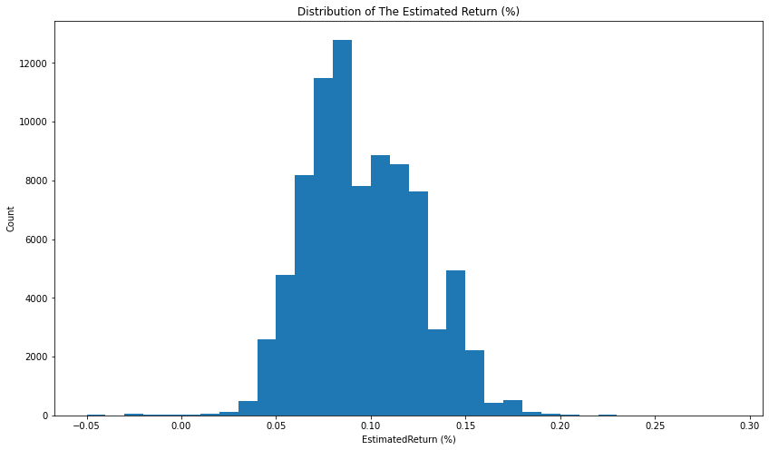

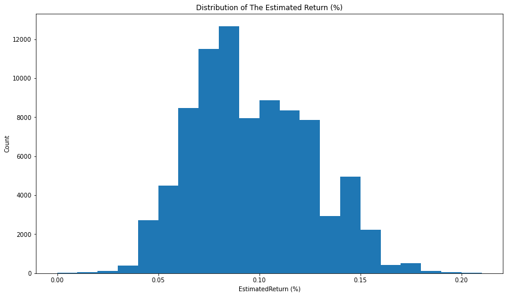

> From investigating the Borrower APR we found that there is no null value in BorrowerAPR, so every borrower in this data set paid for the loan given as the least percentage for BorrowerAPR is 0.04%, is this amount enough to make profit? Comparing Borrower APR to the Estimated Return, there i always a record of return, no matter how small it seems to be. Which shows that 0.04% should be the least Annual Rate to expect returns or profits. Even the low rates has a low amount of Estimated Effective Yield and low Estimated loss, most importantly Estimated Return and so is still suitable for the data set.

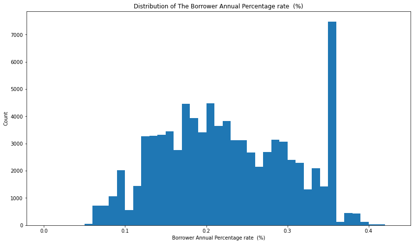

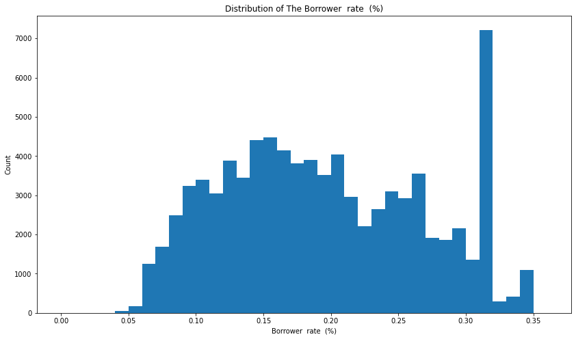

The BorrowerRate and the BorrowerAPR seems strong correlation and they look similar, and it ought to be since the later is the annual percentage rate. The both seems to be strongly hinged on the Lender Yeild.Lender yield is equal to the interest rate on the loan less the servicing fee. The Service Fees seems little. We would look more into this the Bivariate Exploration.

## (Visualization 2)

The company has more Curent Loan status and then followed by completed status it looks good, and considering the accounts in Current Delinquecy which is after comes along with the Pass Due Status, and looking at the Current Delinquencies, its just a small category in the Delinquencies, the ProsperLoan company is safe in business, and its noteworthy to know that Defaulted and Finalpaymentin progress borrowers are very little.Making it a safe balance for the Loan business From the Prosper rating we see that C has the most counts followed by B then A, the least count is the AA rating.The Prosper Rating assigned at the time the listing was created: 0 - N/A, 1 - HR, 2 - E, 3 - D, 4 - C, 5 - B, 6 - A, 7 - AA. Applicable for loans originated after July 2009. California (CA), NewYork (NY), and Texas (TX) is the top #3 Borrower State.

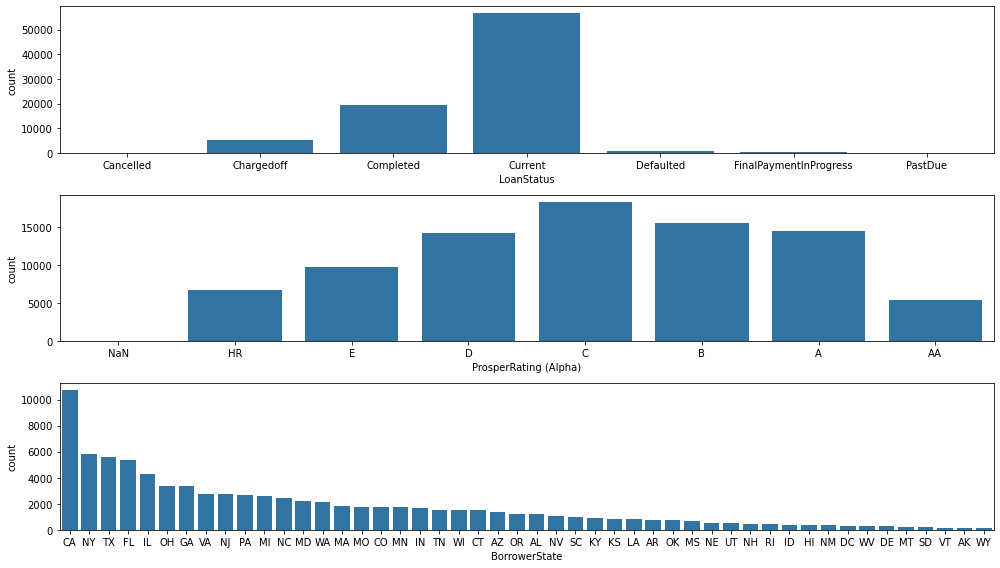

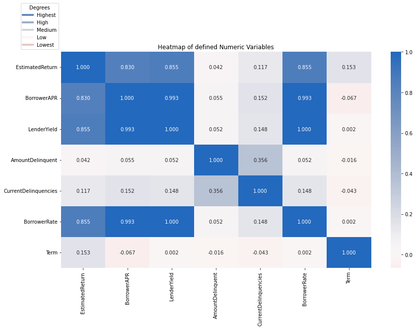

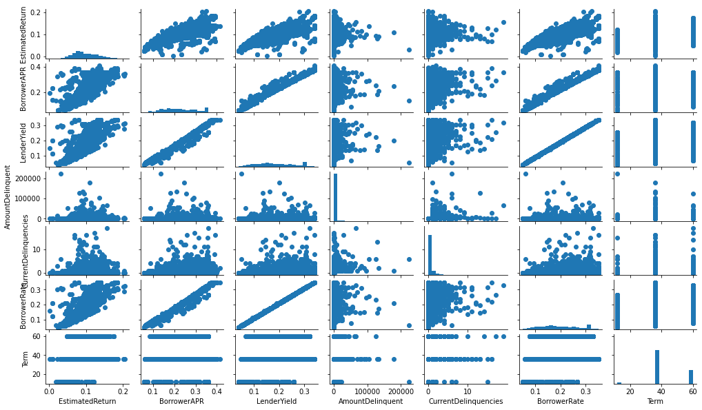

### Relationship between variables

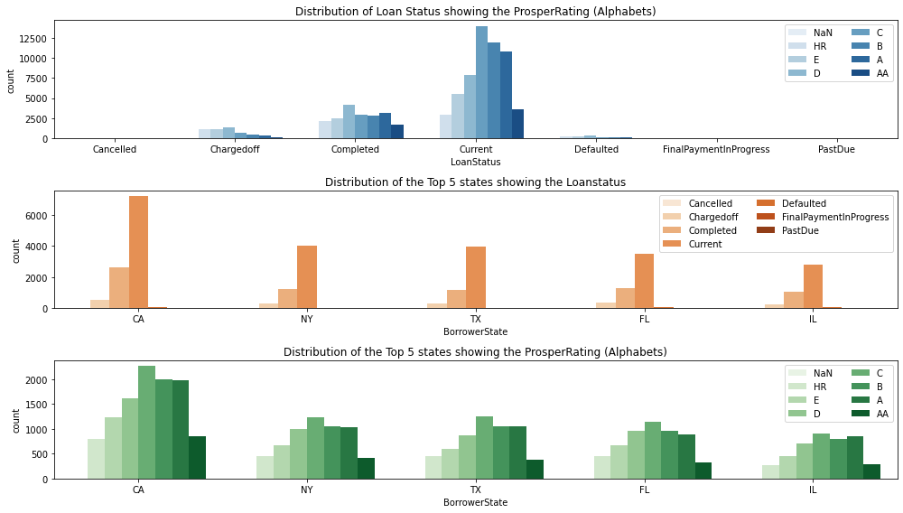

## (Visualization 3)

[figure not shown]

[figure not shown]

Depending on what the ratings are (The Prosper Rating assigned at the time the listing was created: 0 - N/A, 1 - HR, 2 - E, 3 - D, 4 - C, 5 - B, 6 - A, 7 - AA. Applicable for loans originated after July 2009.) It might have been a way to categorize things within the company. Looking closely, here its shows that the highest and lowest ratings have the lowest counts, but also see that the Lender yeild rate affects the Prosper ratings as AA- is the least below 0.10% as it increases up accordingly to HR the highest having concentrated rate after 0.2%